# Analyzing, and Visualizing Data

```python
import pandas as pd
import numpy as np
import matplotlib
import matplotlib.pyplot as plt
import seaborn as sns
%matplotlib inline
```

```python
#first i will read the csv file i cleaned.
twitter_archive_master = pd.read_csv('twitter_archive_master.csv')
```

```python
#check
twitter_archive_master.head()
```

|  | tweet_id | timestamp | source_x | text | expanded_urls | rating_numerator | rating_denominator | name | dog_stage | jpg_url | ... | place | possibly_sensitive | possibly_sensitive_appealable | quoted_status | retweet_count | retweeted | retweeted_status | source_y | truncated | user |
| --- | --- | --- | --- | --- | --- | --- | --- | --- | --- | --- | --- | --- | --- | --- | --- | --- | --- | --- | --- | --- | --- |
| 0 | 892420643555336193 | 2017-08-01 16:23:56 | <a href="http://twitter.com/download/iphone" r... | This is Phineas. He's a mystical boy. Only eve... | https://twitter.com/dog_rates/status/892420643... | 13 | 10 | Phineas | NaN | https://pbs.twimg.com/media/DGKD1-bXoAAIAUK.jpg | ... | NaN | 0.0 | 0.0 | NaN | 8853 | False | NaN | <a href="http://twitter.com/download/iphone" r... | False | {'id': 4196983835, 'id_str': '4196983835', 'na... |
| 1 | 892177421306343426 | 2017-08-01 00:17:27 | <a href="http://twitter.com/download/iphone" r... | This is Tilly. She's just checking pup on you.... | https://twitter.com/dog_rates/status/892177421... | 13 | 10 | Tilly | NaN | https://pbs.twimg.com/media/DGGmoV4XsAAUL6n.jpg | ... | NaN | 0.0 | 0.0 | NaN | 6514 | False | NaN | <a href="http://twitter.com/download/iphone" r... | False | {'id': 4196983835, 'id_str': '4196983835', 'na... |
| 2 | 891815181378084864 | 2017-07-31 00:18:03 | <a href="http://twitter.com/download/iphone" r... | This is Archie. He is a rare Norwegian Pouncin... | https://twitter.com/dog_rates/status/891815181... | 12 | 10 | Archie | NaN | https://pbs.twimg.com/media/DGBdLU1WsAANxJ9.jpg | ... | NaN | 0.0 | 0.0 | NaN | 4328 | False | NaN | <a href="http://twitter.com/download/iphone" r... | False | {'id': 4196983835, 'id_str': '4196983835', 'na... |
| 3 | 891689557279858688 | 2017-07-30 15:58:51 | <a href="http://twitter.com/download/iphone" r... | This is Darla. She commenced a snooze mid meal... | https://twitter.com/dog_rates/status/891689557... | 13 | 10 | Darla | NaN | https://pbs.twimg.com/media/DF_q7IAWsAEuuN8.jpg | ... | NaN | 0.0 | 0.0 | NaN | 8964 | False | NaN | <a href="http://twitter.com/download/iphone" r... | False | {'id': 4196983835, 'id_str': '4196983835', 'na... |
| 4 | 891327558926688256 | 2017-07-29 16:00:24 | <a href="http://twitter.com/download/iphone" r... | This is Franklin. He would like you to stop ca... | https://twitter.com/dog_rates/status/891327558... | 12 | 10 | Franklin | NaN | https://pbs.twimg.com/media/DF6hr6BUMAAzZgT.jpg | ... | NaN | 0.0 | 0.0 | NaN | 9774 | False | NaN | <a href="http://twitter.com/download/iphone" r... | False | {'id': 4196983835, 'id_str': '4196983835', 'na... |

5 rows × 40 columns

## Visualizations and insights

1.

```
Text(0.5,0,'Favorites')
```

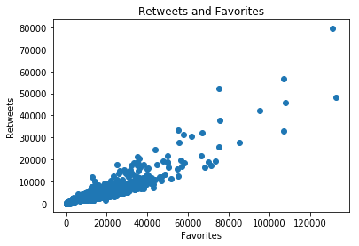

```python
plt.scatter(twitter_archive_master['favorite_count'], twitter_archive_master['retweet_count'])
plt.title('Retweets and Favorites')
plt.ylabel('Retweets')
plt.xlabel('Favorites')
```

- There is a strong correlation between the retweets and the favorites(likes).

2.

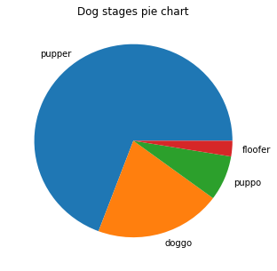

```python
plt.figure(figsize=(5,5))
twitter_archive_master['dog_stage'].value_counts().plot.pie()
plt.title('Dog stages pie chart')
plt.ylabel('');
```

- The most popular dog stage in the tweets is pupper.

3.

```
Text(0.5,1,'Dog breed pie chart')
```

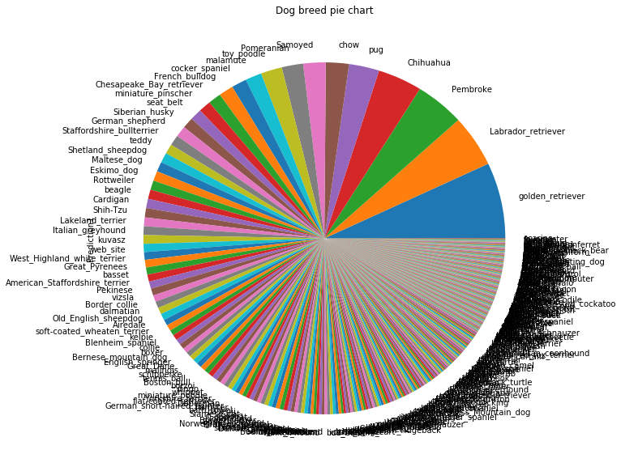

```python
plt.figure(figsize=(10,10))
twitter_archive_master['Prediction1'].value_counts().plot.pie();
plt.title('Dog breed pie chart')
```

- The most popular dog breed in the tweets is golden retriever.

4.

```python
twitter_archive_master['lang'].value_counts()
```

```
en    1987
nl       3
in       2
et       1
eu       1
Name: lang, dtype: int64
```

- The most common language in the tweets is the English language with a very big advantage.

#### Summary

insights:

- There is a strong correlation between the retweets and the favorites(likes).
- The most popular dog stage in the tweets is pupper.
- The most popular dog breed in the tweets is golden retriever.
- The most common language in the tweets is the English language with a very big advantage.

#### in conclusion this dataset offers a lot of useful information and it tells a lot about people and dogs. for example what breeds of dogs is more likely to be liked by people , or what is the highest retweeted dog stage.

#### although it had a lot of issues it still offers a lot of useful information.